# Time Series Analysis

Pablo Rodriguez

1/28/2020

72 patients with asma were given either a placebo (drugP) drugA or drugB.

The **Forced exhalation volume** or FEV was measured before drug administration (Basal) and once every hour up to 8 hours.

The Experimental Unit: Each Patient. Response Variable: FEV (Continuos variable, Normal distribution) Explanatory Variables: Each Patient, Drug & Time. Patient can be considered as a aleatory variable or can be modelled into a covariance matrix resulting either in a conditional or marginal model.

The Data:

```r
# the 9 intervals of 1:72 is because each of the 72 patients were measured once every hour after drug administration and once before. Each interval should have the same numbers to indicate the same person.

patient = c(
  (1:72),(1:72),(1:72),(1:72),(1:72),(1:72),(1:72),(1:72),(1:72)
)

drugA = "A"
drugB = "B"
drugP = "P"

# REPLICATE 24, since it is a balanced design, each drug was administered to 24 inidividuals.
drug = c(
  replicate(24, drugA), replicate(24, drugB), replicate(24, drugP),
  replicate(24, drugA), replicate(24, drugB), replicate(24, drugP),
  replicate(24, drugA), replicate(24, drugB), replicate(24, drugP),
  replicate(24, drugA), replicate(24, drugB), replicate(24, drugP),
  replicate(24, drugA), replicate(24, drugB), replicate(24, drugP),
  replicate(24, drugA), replicate(24, drugB), replicate(24, drugP),
  replicate(24, drugA), replicate(24, drugB), replicate(24, drugP),
  replicate(24, drugA), replicate(24, drugB), replicate(24, drugP),
  replicate(24, drugA), replicate(24, drugB), replicate(24, drugP)
)

time = c(
  replicate(72, "Basal"), replicate(72, "1hs"), replicate(72, "2hs"),
  replicate(72, "3hs"), replicate(72, "4hs"), replicate(72, "5hs"),
  replicate(72, "6hs"), replicate(72, "7hs"), replicate(72, "8hs")
)

#FEV that was measured for each patient at each hour
fev = c(
  2.46, 3.5,  1.96,  3.44,  2.8,  2.36,  1.77,  2.64,  2.3,  2.27,  2.44,  2.04,
  2.77,  2.96,  3.11,  1.47,  2.73,  3.25,  2.73,  3.3,  2.85,  2.72,  3.68,  2.49,
  2.3,  2.91,  2.08,  3.02,  3.26,  2.29,  1.96,  2.7,  2.5,  2.35,  2.34,  2.2,
  2.78,  3.43,  3.07,  1.21,  2.6,  2.61,  2.48,  3.73,  2.54,  2.83,  3.47,  2.79,
  2.14,  3.37,  1.88,  3.1,  2.91,  2.29,  2.2,  2.7,  2.25,  2.48,  2.12,  2.37,
  2.73,  3.15,  2.52,  1.48,  2.52,  2.9,  2.83,  3.5,  2.86,  2.42,  3.66,  2.88,
  2.68,  3.95,  2.28,  4.08,  4.09,  3.79,  3.82,  3.67,  4.12,  2.77,  3.77,  2,
  3.36,  4.31,  3.88,  1.97,  2.91,  3.59,  2.88,  4.04,  3.38,  4.49,  4.17,  3.73,
  3.41,  3.92,  2.52,  4.43,  4.55,  4.25,  3,  4.06,  4.37,  2.83,  4.06,  2.82,  3.18,
  4.39,  3.9,  2.31,  3.19,  3.54,  2.99,  4.37,  3.26,  4.72,  4.27,  4.1, 2.36,  3.03,
  1.99,  3.24,  3.35,  3.04,  2.46,  2.85,  3.45,  2.56,  2.19,  2.14,  2.57,  2.9,  3.02,
  1.35,  2.61,  2.91,  2.78,  3.81,  3.06,  2.87,  3.98,  3.04,  2.76,  3.65,  2.34,  3.87,
  3.9,  3.97,  3.44,  3.47,  3.71,  2.77,  3.73,  1.91,  3.42,  4.02,  3.92,  1.9,  2.99,
  3.54,  3.06,  3.94,  3.42,  4.35,  4.3,  3.51,  3.48,  4.02,  2.44,  4.3,  4.58,  4.37,
  2.8,  3.98,  4.06,  2.79,  3.68,  1.9,  3.13,  4.63,  3.98,  2.19,  3.18,  3.45,  3.02,
  4.2,  3.39,  4.97,  4.5,  3.85,  2.36,  3.02,  1.62,  3.37,  3.92,  3.28,  3.22,  2.81,
  3.48,  2.52,  2.44,  1.92,  3.08,  2.8,  3.21,  1.15,  2.59,  2.89,  2.89,  3.77,  2.95,
  3.08,  3.77,  3,  2.5,  2.93,  2.29,  3.79,  3.54,  3.78,  3.46,  3.19,  3.57,  2.75,
  3.67,  1.88,  3.28,  3.38,  3.71,  1.45,  2.87,  3.17,  2.75,  3.84,  3.28,  4.38,  4.16,
  3.16,  3.41,  4.04,  2.27,  4.08,  4.44,  4.1,  2.59,  4.06,  3.68,  2.82,  3.59,  2.57,
  3.11,  4.19,  4.09,  2.21,  3.15,  3.25,  3.02,  4.17,  3.27,  4.99,  4.34,  4.27,  2.28,
  3.19,  1.65,  3.54,  3.69,  3.17,  2.65,  2.96,  3.8,  2.67,  2.41,  1.75,  2.62,  3.17,
  3.17,  1.24,  2.77,  3.01,  2.77,  3.78,  3.07,  3.02,  3.65,  3.24,  2.3,  2.53,  2.43,
  3.3,  3.35,  3.69,  3.02,  2.19,  3.49,  2.75,  3.56,  2.09,  3.3,  3.31,  3.59,  1.45,
  2.88,  2.92,  2.71,  3.99,  2.94,  4.36,  4.07,  3.26,  3.49,  3.64,  2.23,  4.01,  4.04,
  4.2,  2.42,  3.93,  3.64,  2.79,  3.27,  2.3,  2.97,  4,  4.03,  2.09,  3.14,  3.01,  2.94,
  4.19,  3.2,  4.96,  4,  4.01,  2.35,  2.98,  1.68,  3.31,  3.97,  2.99,  3.02,  2.69,  3.6,
  2.6,  2.55,  1.58,  2.91,  2.39,  3.13,  1.32,  2.73,  2.74,  2.77,  3.9,  3.1,  3.14,  3.81,
  3.37,  2.14,  3.04,  2.06,  3.8,  3.15,  3.31,  2.98,  2.85,  3.64,  2.71,  3.59,  2.08,  3.31,
  3.46,  3.57,  1.24,  2.84,  3.48,  2.83,  3.9,  2.96,  3.77,  3.87,  3.07,  3.33,  3.29,  2.01,
  3.62,  4.33,  3.84,  1.61,  3.61,  3.17,  2.8,  2.6,  1.67,  3.06,  4.01,  4.07,  1.75,  3.08,
  3.07,  2.69,  4.07,  3.32,  4.95,  4.11,  3.78,  2.31,  3.01,  1.65,  2.81,  3.94,  3.31,  2.25,
  2.18,  2.83,  2.68,  2.93,  1.51,  2.71,  3.01,  3.38,  0.95,  2.7,  2.71,  2.69,  3.8,  2.67,
  3.67,  3.77,  2.69,  2.4,  3.37,  2.18,  3.24,  3.23,  2.83,  3.1,  2.68,  3.38,  2.75,  3.35,
  1.98,  2.99,  3.49,  3.48,  1.24,  2.67,  3.05,  2.58,  3.89,  3.12,  4.23,  3.87,  2.77,  3.2,
  3.1,  2.26,  3.23,  3.87,  3.43,  1.83,  2.91,  3.37,  2.76,  2.72,  1.9,  3.27,  3.66,  3.56,
  1.72,  2.96,  2.65,  2.66,  3.86,  3.09,  4.82,  3.93,  3.14,  2.62,  2.75,  1.85,  3.58,  3.63,
  3.21,  1.5,  1.91,  3.17,  2.64,  3.08,  1.94,  2.39,  3.22,  3.25,  1.24,  2.72,  2.86,  2.65,
  3.78,  2.68,  3.84,  3.89,  2.89,  2.33,  3.14,  2.28,  2.98,  3.46,  2.72,  2.79,  2.6,  2.28,
  2.52,  3.32,  1.7,  3.01,  3.38,  3.42,  1.17,  2.69,  3.27,  2.68,  3.89,  2.98,  3.83,  3.85,
  2.92,  3.07,  2.7,  2.34,  2.46,  3.75,  3.79,  1.21,  2.07,  3.2,  2.64,  2.22,  2.07,  3.24,
  3.47,  3.83,  1.8,  2.97,  2.47,  2.68,  3.89,  3.25,  4.56,  3.68,  3.94,  2.12,  2.7,  1.96,
  3.76,  2.92,  2.98,  2.37,  2.21,  3.22,  2.65,  3.11,  1.84,  2.42,  2.75,  3.29,  1.04,  2.71,
  2.95,  2.84,  3.7,  2.94,  3.55,  3.63,  2.89,  2.2,  2.62,  2.29,  2.91,  3.27,  3,  2.88,  2.73,
  3.72,  2.6,  3.18,  1.4,  3.08,  3.35,  3.63,  1.27,  2.77,  2.96,  2.42,  2.98,  2.99,  3.89,  3.82,
  3,  3.15,  2.69,  2.44,  2.97,  3.81,  3.74,  1.5,  2.67,  3.25,  2.69,  2.68,  1.76,  3.33,  3.22,
  3.75,  1.36,  2.85,  2.55,  2.7,  3.89,  3.15,  4.49,  3.77,  3.69,  2.42,  2.84,  1.3,  3.05,  3.31,
  2.82,  1.94,  1.71,  3.13,  2.61,  3.06,  1.76,  2.73,  3.14,  3.35,  1.16,  2.75,  2.66,  2.8,  3.61,
  2.89,  3.75,  3.74,  2.76
)

#dataframe for working with models:

asma = data.frame(patient, drug, time, fev)

asma$patient = as.factor(asma$patient)
```

```r
#Libraries that will be used in this analysis:
library(ggplot2)
library(tidyr)
library(GGally)
library(doBy)
library(nlme)
library(emmeans)
library(dplyr)
library(ggpubr)
```

Firstly, I will visualize the data, to see if there are any patterns that may be of interest.

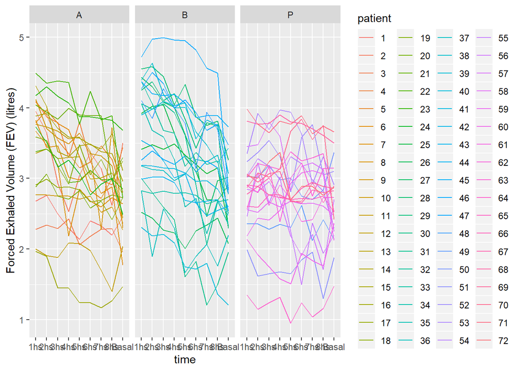

```r
##Descriptive analysis
spagPlot = ggplot(data = asma, aes(time, y = fev, group = patient))
spagPlot + geom_line(aes(colour = patient)) +
  facet_grid(. ~ drug) +
  labs(y = "Forced Exhaled Volume (FEV) (litres)")
```

This first visualization of the data clearly shows that there is an interaction between the different time variables (Here I will state that each hour is a variable of its own) since all lines cross each other. If time number “X” didn’t have an interactive effect with time number “Y” the lines should be paralel. This effect can be seen for each of the three drugs: A, B & P.

Next I will analyze the way the mean of the data for each group behaves:

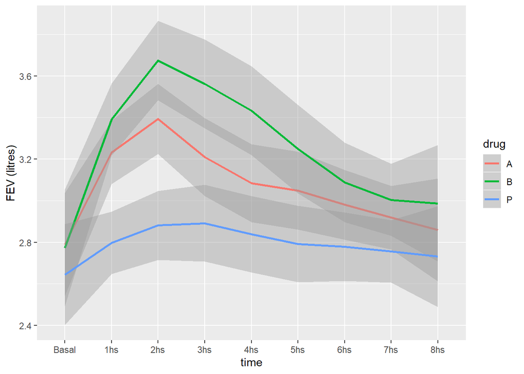

```r
#Here I re-order the variables, making Basal the first one to be plotted (since this is the way the data was measured)

asma$time = factor(asma$time, levels = c("Basal", "1hs", "2hs", "3hs", "4hs", "5hs", "6hs", "7hs", "8hs"))

tendencyPlot = ggplot(data = asma, aes(x = time, y = fev, colour = drug, group = drug))
tendencyPlot + geom_smooth(se = TRUE) +
  labs(y = "FEV (litres)")
```

Since the same individual was measured throughout this 8hs time period the data is correlated. If two variables are independent their **covariance** = 0, thought the reciprocal is not necessarily true. I will now study the **covariance matrix** of the time variables:

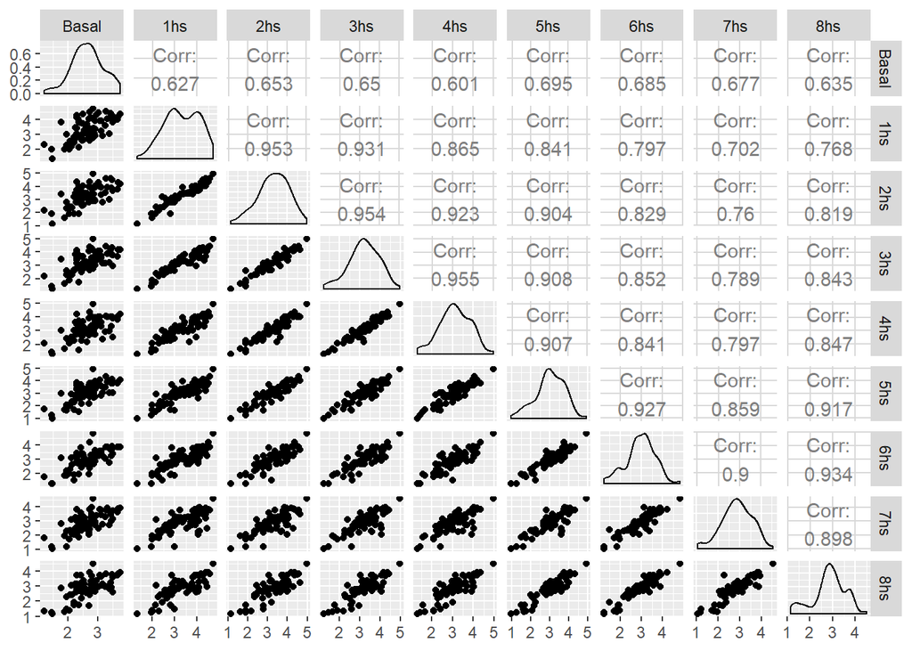

```r
#I transform each time variable into an independent column
asma_wide = spread(asma, time, fev)
time_wide = asma_wide[3:11]
##ggpairs to analyze the correlation between variables
ggpairs(time_wide)
```

The plot shows association between time variables are positivly

```r
#covariance matrix
round(cov(time_wide),2)
```

```
##       Basal  1hs  2hs  3hs  4hs  5hs  6hs  7hs  8hs
## Basal  0.28 0.25 0.27 0.26 0.23 0.29 0.26 0.25 0.24
## 1hs    0.25 0.58 0.56 0.53 0.48 0.50 0.43 0.38 0.42
## 2hs    0.27 0.56 0.60 0.55 0.52 0.54 0.45 0.41 0.45
## 3hs    0.26 0.53 0.55 0.56 0.52 0.53 0.45 0.41 0.45
## 4hs    0.23 0.48 0.52 0.52 0.54 0.52 0.43 0.41 0.44
## 5hs    0.29 0.50 0.54 0.53 0.52 0.60 0.50 0.47 0.50
## 6hs    0.26 0.43 0.45 0.45 0.43 0.50 0.49 0.44 0.46
## 7hs    0.25 0.38 0.41 0.41 0.41 0.47 0.44 0.49 0.45
## 8hs    0.24 0.42 0.45 0.45 0.44 0.50 0.46 0.45 0.50
```

The diagonal of this matrix are values that correspond variance of each variable. If observations were homoscedastic then they would all be the same value, but this isn’t the case for which we can already see that the case of homoscedasticity will have to be tested to see if it is significantly different. If the data were truly independent, and since the matrix is squared and symmetrical, we would see on either side of the diaganol the value of 0. This isn’t the case either, which is another indicator for the lack of independency between variables.

```
## Color gradient midpoint set at median correlation to 0.84
```

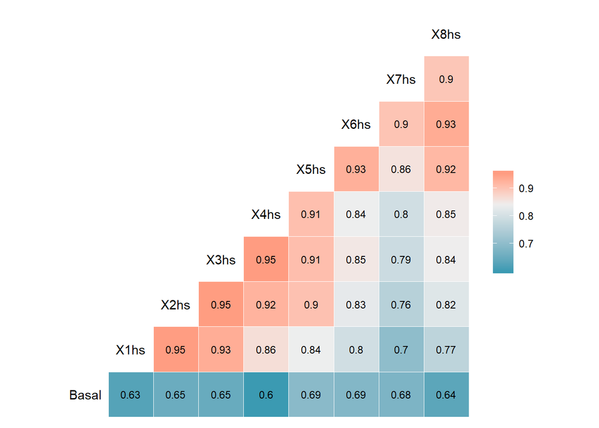

```r
#Heatmap
ggcorr(time_wide, label = TRUE, label_size = 3,limits = FALSE, midpoint = NULL, label_round = 2) #heatmap
```

This heatmap facilitates the relationship of association between variables.Values in red are more closely correlated than those in blue. The pattern becomes clear: Hours closer to eachother have more similar values of FEV than those that are further apart.

For the case of this particular study I will include “basal” as an explanatory variable:

```r
keycol = "time"
valuecol = "fev"
gathercols = c("1hs", "2hs", "3hs", "4hs", "5hs", "6hs", "7hs", "8hs")
#another dataframe
asma2 = gather_(asma_wide, keycol, valuecol, gathercols)
```

I will now propose 5 different models for explaining this set of data:

Composed Symmetry:

This model assumes that the variance of each time and covariance between times, which basically means that the assumption made is that for each pair of *repeated measurments* their correlation value will be the same.

```r
model1 = gls(fev ~ drug*time + Basal, correlation = corCompSymm(form =~ 1|patient), asma2)
getVarCov(model1)
```

```
## Marginal variance covariance matrix
##         [,1]    [,2]    [,3]    [,4]    [,5]    [,6]    [,7]    [,8]
## [1,] 0.26938 0.20626 0.20626 0.20626 0.20626 0.20626 0.20626 0.20626
## [2,] 0.20626 0.26938 0.20626 0.20626 0.20626 0.20626 0.20626 0.20626
## [3,] 0.20626 0.20626 0.26938 0.20626 0.20626 0.20626 0.20626 0.20626
## [4,] 0.20626 0.20626 0.20626 0.26938 0.20626 0.20626 0.20626 0.20626
## [5,] 0.20626 0.20626 0.20626 0.20626 0.26938 0.20626 0.20626 0.20626
## [6,] 0.20626 0.20626 0.20626 0.20626 0.20626 0.26938 0.20626 0.20626
## [7,] 0.20626 0.20626 0.20626 0.20626 0.20626 0.20626 0.26938 0.20626
## [8,] 0.20626 0.20626 0.20626 0.20626 0.20626 0.20626 0.20626 0.26938
##   Standard Deviations: 0.51902 0.51902 0.51902 0.51902 0.51902 0.51902 0.51902 0.51902
```

Composed Symmetry. Variances are *not* the same:

```r
model2 = gls(fev ~ drug*time + Basal, correlation = corCompSymm(form =~ 1|patient), asma2, weights = varIdent(form = ~ 1 | time))
getVarCov(model2)
```

```
## Marginal variance covariance matrix
##         [,1]    [,2]    [,3]    [,4]    [,5]    [,6]    [,7]    [,8]
## [1,] 0.23965 0.18398 0.18398 0.18398 0.18398 0.18398 0.18398 0.18398
## [2,] 0.18398 0.23965 0.18398 0.18398 0.18398 0.18398 0.18398 0.18398
## [3,] 0.18398 0.18398 0.23965 0.18398 0.18398 0.18398 0.18398 0.18398
## [4,] 0.18398 0.18398 0.18398 0.23965 0.18398 0.18398 0.18398 0.18398
## [5,] 0.18398 0.18398 0.18398 0.18398 0.23965 0.18398 0.18398 0.18398
## [6,] 0.18398 0.18398 0.18398 0.18398 0.18398 0.23965 0.18398 0.18398
## [7,] 0.18398 0.18398 0.18398 0.18398 0.18398 0.18398 0.23965 0.18398
## [8,] 0.18398 0.18398 0.18398 0.18398 0.18398 0.18398 0.18398 0.23965
##   Standard Deviations: 0.48954 0.48954 0.48954 0.48954 0.48954 0.48954 0.48954 0.48954
```

Autoregressive correlation of the first order:

This model supposes that correlation between times diminish exponentially regarding the distance between times. So for a given covaraince “P” at time 1 and time 2, the covariance between time 1 and time 3 would be x$^2$

```r
model3 = gls(fev ~ drug*time + Basal, correlation = corAR1(form =~ 1|patient), asma2)
getVarCov(model3)
```

```
## Marginal variance covariance matrix
##          [,1]    [,2]    [,3]    [,4]    [,5]    [,6]    [,7]     [,8]
## [1,] 0.266140 0.22795 0.19525 0.16723 0.14324 0.12269 0.10509 0.090009
## [2,] 0.227950 0.26614 0.22795 0.19525 0.16723 0.14324 0.12269 0.105090
## [3,] 0.195250 0.22795 0.26614 0.22795 0.19525 0.16723 0.14324 0.122690
## [4,] 0.167230 0.19525 0.22795 0.26614 0.22795 0.19525 0.16723 0.143240
## [5,] 0.143240 0.16723 0.19525 0.22795 0.26614 0.22795 0.19525 0.167230
## [6,] 0.122690 0.14324 0.16723 0.19525 0.22795 0.26614 0.22795 0.195250
## [7,] 0.105090 0.12269 0.14324 0.16723 0.19525 0.22795 0.26614 0.227950
## [8,] 0.090009 0.10509 0.12269 0.14324 0.16723 0.19525 0.22795 0.266140
##   Standard Deviations: 0.51588 0.51588 0.51588 0.51588 0.51588 0.51588 0.51588 0.51588
```

```r
model4 = gls(fev ~ drug*time + Basal, correlation = corCompSymm(form =~ 1|patient), asma2, weights = varIdent(form = ~ 1 | time))
getVarCov(model4)
```

```
## Marginal variance covariance matrix
##         [,1]    [,2]    [,3]    [,4]    [,5]    [,6]    [,7]    [,8]
## [1,] 0.23965 0.18398 0.18398 0.18398 0.18398 0.18398 0.18398 0.18398
## [2,] 0.18398 0.23965 0.18398 0.18398 0.18398 0.18398 0.18398 0.18398
## [3,] 0.18398 0.18398 0.23965 0.18398 0.18398 0.18398 0.18398 0.18398
## [4,] 0.18398 0.18398 0.18398 0.23965 0.18398 0.18398 0.18398 0.18398
## [5,] 0.18398 0.18398 0.18398 0.18398 0.23965 0.18398 0.18398 0.18398
## [6,] 0.18398 0.18398 0.18398 0.18398 0.18398 0.23965 0.18398 0.18398
## [7,] 0.18398 0.18398 0.18398 0.18398 0.18398 0.18398 0.23965 0.18398
## [8,] 0.18398 0.18398 0.18398 0.18398 0.18398 0.18398 0.18398 0.23965
##   Standard Deviations: 0.48954 0.48954 0.48954 0.48954 0.48954 0.48954 0.48954 0.48954
```

Finally the last model I propose for modelling the covariance matrix is the *“Unstructured Matrix”*:

There are no restrictions on the matrix parameters. It is the least “parsimonious”, each covariance must be estimated.

```r
model5 = gls(fev ~ drug*time + Basal, correlation = corSymm(form =~ 1|patient), asma2)
getVarCov(model5)
```

```
## Marginal variance covariance matrix
##         [,1]    [,2]    [,3]    [,4]    [,5]    [,6]    [,7]    [,8]
## [1,] 0.26467 0.23843 0.23576 0.20718 0.18119 0.18029 0.13272 0.16837
## [2,] 0.23843 0.26467 0.24099 0.22902 0.21071 0.18381 0.14981 0.18112
## [3,] 0.23576 0.24099 0.26467 0.24009 0.21212 0.19635 0.16386 0.19186
## [4,] 0.20718 0.22902 0.24009 0.26467 0.21395 0.19133 0.17070 0.19507
## [5,] 0.18119 0.21071 0.21212 0.21395 0.26467 0.22473 0.18971 0.22059
## [6,] 0.18029 0.18381 0.19635 0.19133 0.22473 0.26467 0.21254 0.23109
## [7,] 0.13272 0.14981 0.16386 0.17070 0.18971 0.21254 0.26467 0.21365
## [8,] 0.16837 0.18112 0.19186 0.19507 0.22059 0.23109 0.21365 0.26467
##   Standard Deviations: 0.51446 0.51446 0.51446 0.51446 0.51446 0.51446 0.51446 0.51446
```

I evaluate which model has a better AIC:

```r
AIC(model1, model2, model3, model4, model5)
```

```
##        df      AIC
## model1 27 401.2902
## model2 34 409.8817
## model3 27 329.0350
## model4 34 409.8817
## model5 54 261.4179
```

And I will also evaluate the models through ANOVA in order to compare degrees of freedom, another factor I will take into account in order to determine which is the best model for the data:

```r
anova(model1, model2, model3, model4, model5)
```

```
##        Model df      AIC      BIC     logLik   Test   L.Ratio p-value
## model1     1 27 401.2902 517.7070 -173.64508
## model2     2 34 409.8817 556.4807 -170.94086 1 vs 2   5.40844  0.6102
## model3     3 27 329.0350 445.4519 -137.51752 2 vs 3  66.84668  <.0001
## model4     4 34 409.8817 556.4807 -170.94086 3 vs 4  66.84668  <.0001
## model5     5 54 261.4179 494.2516  -76.70896 4 vs 5 188.46380  <.0001
```

I have to make sure that the residues comply with the assumptions of the model:

$\Upsilon$$_{ijk}$ = $\mu$ + $\alpha$$_i$ + $\beta$$_j$ + $\alpha$*$\beta$$_{ij}$ + $\upsilon$$_k$ + $\varepsilon$$_{ijk}$

Where:

i = 1 to 3 (three treatments)

j = 1 to 9 (nine different time intervals)

k = 1 to 72 (72 experimental units)

Assumptions: ($\varepsilon$$_{ijk}$ $\sim$ N(0,$\sum$$_k$))

$\Upsilon$$_{ijk}$ = Each individual’s response at each time

$\mu$ = population mean

$\alpha$$_i$ = fixed effect of treatment **“i”**

$\beta$$_j$ = fixed effect of time **“j”**

$\alpha$*$\beta$$_{ij}$ = effect of the interaction between time and treatment

$\upsilon$$_k$ = Basal value

$\varepsilon$$_{ijk}$ = aleatory error

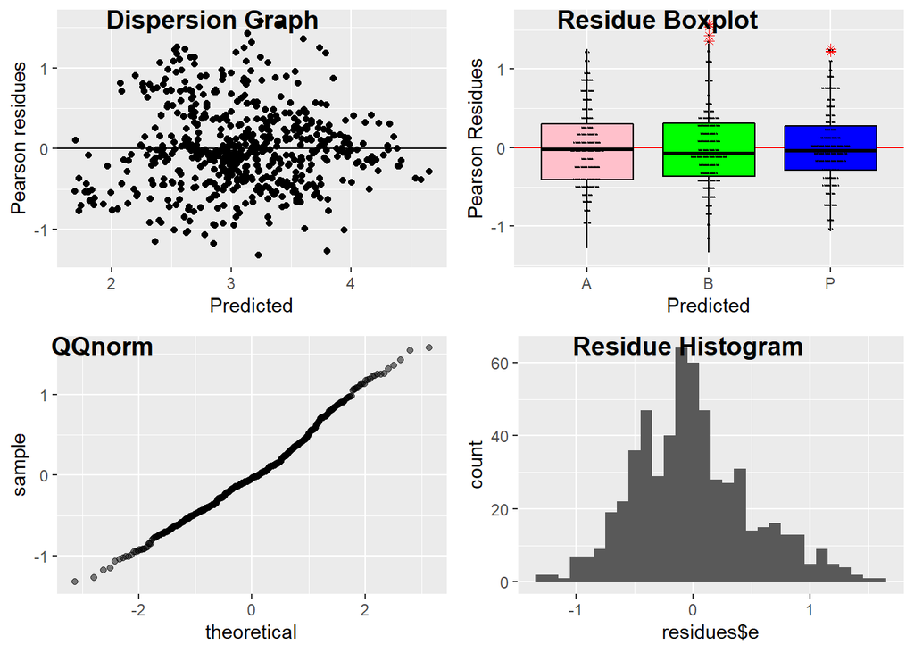

```r
#Pearson residues
e = resid(model5)
#predicted
pre = predict(model5)


residues = data.frame(e,pre)

rPlot1 = ggplot(data = residues, aes(x = pre, y = e)) +
  labs(x = "Predicted", y="Pearson residues") +
  geom_abline(slope = 0, intercept = 0) +
  geom_point()

rPlot2 = ggplot(data = residues, aes(asma2$drug, residues$e)) +
  labs(x = "Predicted", y = "Pearson Residues") +
  geom_abline(slope = 0, intercept = 0, colour = "red") +
  geom_boxplot(col = c("black", "black", "black"),
               fill = c("pink", "green", "blue"),
               outlier.color = "red",
               outlier.shape = 8) +
  geom_dotplot(binaxis = 'y', stackdir = 'center', dotsize = .2)

ggQQ = function(LM) # argument: a linear model
{
  y = quantile(LM$resid[!is.na(LM$resid)], c(0.25, 0.75))
  x = qnorm(c(0.25, 0.75))
  slope = diff(y)/diff(x)
  int = y[1L] - slope * x[1L]
  p = ggplot(LM, aes(sample = e)) +
    stat_qq(alpha = 0.5) +
    geom_abline(slope = slope, intercept = int, color="blue")

  return(p)
}

rPlot3 = ggQQ(residues)

rPlot4 = ggplot(data = residues, aes(x = residues$e)) +
  geom_histogram(binwidth = .1)

figure = ggarrange(rPlot1, rPlot2, rPlot3, rPlot4,
                   labels = c("Dispersion Graph", "Residue Boxplot", "QQnorm", "Residue Histogram"),
                   ncol = 2, nrow = 2)
figure
```

```r
shapiro.test(e)
```

```
##
##  Shapiro-Wilk normality test
##
## data:  e
## W = 0.98629, p-value = 3.076e-05
```

```r
emmeans(model5, pairwise ~ drug | time)
```

```
## Analytical Satterthwaite method not available; using boot-satterthwaite
```

```
## $emmeans
## time = 1hs:
##  drug emmean    SE  df lower.CL upper.CL
##  A      3.47 0.105 103     3.26     3.68
##  B      3.69 0.105 103     3.48     3.90
##  P      2.83 0.105 103     2.62     3.04
##
## time = 2hs:
##  drug emmean    SE  df lower.CL upper.CL
##  A      3.40 0.105 103     3.19     3.60
##  B      3.63 0.105 103     3.42     3.83
##  P      2.89 0.105 103     2.68     3.10
##
## time = 3hs:
##  drug emmean    SE  df lower.CL upper.CL
##  A      3.18 0.105 103     2.97     3.39
##  B      3.58 0.105 103     3.37     3.78
##  P      2.90 0.105 103     2.69     3.11
##
## time = 4hs:
##  drug emmean    SE  df lower.CL upper.CL
##  A      3.04 0.105 103     2.84     3.25
##  B      3.44 0.105 103     3.23     3.65
##  P      2.87 0.105 103     2.66     3.08
##
## time = 5hs:
##  drug emmean    SE  df lower.CL upper.CL
##  A      3.05 0.105 103     2.84     3.26
##  B      3.25 0.105 103     3.04     3.46
##  P      2.77 0.105 103     2.56     2.98
##
## time = 6hs:
##  drug emmean    SE  df lower.CL upper.CL
##  A      2.98 0.105 103     2.77     3.19
##  B      3.08 0.105 103     2.88     3.29
##  P      2.82 0.105 103     2.61     3.02
##
## time = 7hs:
##  drug emmean    SE  df lower.CL upper.CL
##  A      2.87 0.105 103     2.66     3.08
```

[output cut: 48 more lines]

```
##
## time = 7hs:
##  contrast estimate    SE  df t.ratio p.value
##  A - B     -0.1090 0.149 103 -0.734  0.7441
##  A - P      0.0819 0.149 103  0.551  0.8461
##  B - P      0.1909 0.149 103  1.285  0.4067
##
## time = 8hs:
##  contrast estimate    SE  df t.ratio p.value
##  A - B     -0.1527 0.149 103 -1.028  0.5608
##  A - P      0.1240 0.149 103  0.835  0.6825
##  B - P      0.2767 0.149 103  1.863  0.1547
##
## Degrees-of-freedom method: boot-satterthwaite
## P value adjustment: tukey method for comparing a family of 3 estimates
```

```r
CLD(emmeans(model5, pairwise ~ drug | time))
```

```
## Analytical Satterthwaite method not available; using boot-satterthwaite
```

```
## time = 1hs:
##  drug emmean    SE  df lower.CL upper.CL .group
##  P      2.83 0.105 102     2.62     3.04  1
##  A      3.47 0.105 102     3.26     3.68   2
##  B      3.69 0.105 102     3.48     3.90   2
##
## time = 2hs:
##  drug emmean    SE  df lower.CL upper.CL .group
##  P      2.89 0.105 102     2.68     3.10  1
##  A      3.40 0.105 102     3.19     3.60   2
##  B      3.63 0.105 102     3.42     3.83   2
##
## time = 3hs:
##  drug emmean    SE  df lower.CL upper.CL .group
##  P      2.90 0.105 102     2.69     3.11  1
##  A      3.18 0.105 102     2.97     3.39  1
##  B      3.58 0.105 102     3.37     3.78   2
##
## time = 4hs:
##  drug emmean    SE  df lower.CL upper.CL .group
##  P      2.87 0.105 102     2.66     3.08  1
##  A      3.04 0.105 102     2.84     3.25  1
##  B      3.44 0.105 102     3.23     3.65   2
##
## time = 5hs:
##  drug emmean    SE  df lower.CL upper.CL .group
##  P      2.77 0.105 102     2.56     2.98  1
##  A      3.05 0.105 102     2.84     3.26  12
##  B      3.25 0.105 102     3.04     3.46   2
##
## time = 6hs:
##  drug emmean    SE  df lower.CL upper.CL .group
##  P      2.82 0.105 102     2.61     3.02  1
##  A      2.98 0.105 102     2.77     3.19  1
##  B      3.08 0.105 102     2.88     3.29  1
##
## time = 7hs:
##  drug emmean    SE  df lower.CL upper.CL .group
##  P      2.78 0.105 102     2.58     2.99  1
##  A      2.87 0.105 102     2.66     3.08  1
##  B      2.98 0.105 102     2.77     3.18  1
##
## time = 8hs:
##  drug emmean    SE  df lower.CL upper.CL .group
##  P      2.73 0.105 102     2.52     2.94  1
##  A      2.86 0.105 102     2.65     3.06  1
##  B      3.01 0.105 102     2.80     3.22  1
##
## Degrees-of-freedom method: boot-satterthwaite
## Confidence level used: 0.95
## P value adjustment: tukey method for comparing a family of 3 estimates
## significance level used: alpha = 0.05
```

```r
finalPlot1 = ggplot(data = asma2, aes(x = time, y = fev, colour = drug, group = drug)) +
  geom_smooth(se = FALSE)+ labs(y = "FEV (litres)")

summary = asma2 %>% group_by(time, drug) %>%
  summarize(mn = mean(fev), sd = sd(fev), n = n() )
summary$se = summary$sd / sqrt(summary$n)

finalPlot2 = ggplot(summary, aes(x=time, y = mn, colour = drug)) +
  geom_line(aes(colour = drug)) +
  geom_point() +
  geom_errorbar(aes(ymin = mn - se, ymax = mn + se), width = .2) +
  labs(y = "FEV (litres)")

figure2 = ggarrange(finalPlot1, finalPlot2,
                    labels = c("FEV vs Time", "FEV vs Time + error"))
```

```
## geom_path: Each group consists of only one observation. Do you need to adjust
## the group aesthetic?
```

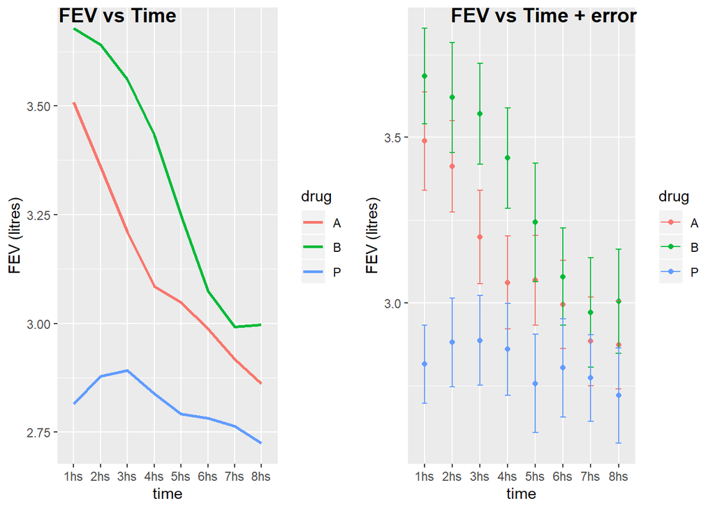

```r
figure2
```